# Capstone Exploratory Portion

Max Davis

7/26/2019

```r
library(ggplot2)
```

**What is the relationship between wind speed and active power?**

From the plot below we can observe a strong positive relationship between Active Power and Wind Speed, and this makes intuitive sense.

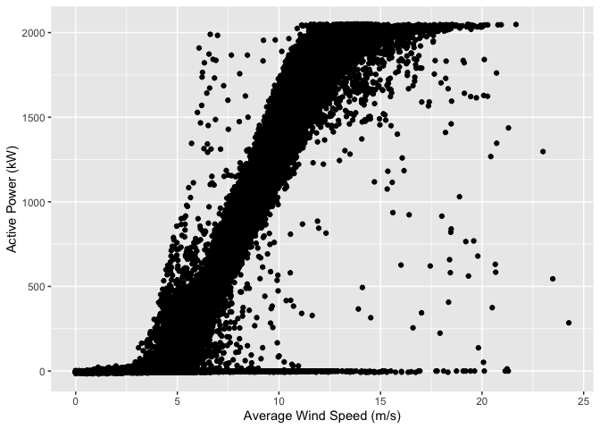

```r
ggplot(haute, aes(x = Wind_speed_avg, y = Active_power_avg))+
  geom_point() +
  labs(x = "Average Wind Speed (m/s)", y = "Active Power (kW)")
```

The same will be roughly true no matter which turbine we are looking at. Below, the data is faceted by individual turbine.

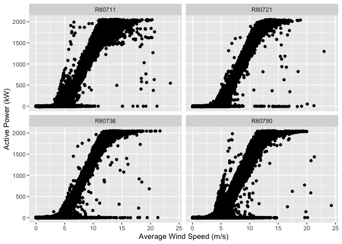

```r
ggplot(haute, aes(x = Wind_speed_avg, y = Active_power_avg))+
  geom_point() +
  labs(x = "Average Wind Speed (m/s)", y = "Active Power (kW)") +
  facet_wrap(~Wind_turbine_name)
```

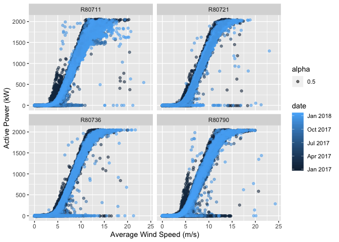

```r
ggplot(haute, aes(x = Wind_speed_avg, y = Active_power_avg))+
  geom_point(aes(color = date, alpha = .5)) +
  labs(x = "Average Wind Speed (m/s)", y = "Active Power (kW)") +
  facet_wrap(~Wind_turbine_name)
```

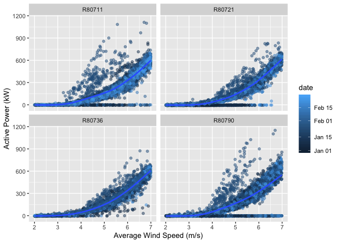

```r
haute %>%
  filter(date < as.Date("2017-2-28")) %>%
  filter(Wind_speed_avg < 7) %>%
  filter(Wind_speed_avg > 2) %>%
  ggplot(., aes(x = Wind_speed_avg, y = Active_power_avg))+
  labs(x = "Average Wind Speed (m/s)", y = "Active Power (kW)") +
  geom_point(aes(color = date), alpha = .5) +
  facet_wrap(~Wind_turbine_name) +
  geom_smooth()
```

Now lets try comparing wind speeds over time, and how the active power is affected. Maybe that will clarify some things. Over a full year period, the plot below shows some densely packed periods of wind increase and decrease, with a generally corresponding increase and decrease of Active Power. The dark spikes seem to indicate low to zero active power at high wind speeds.

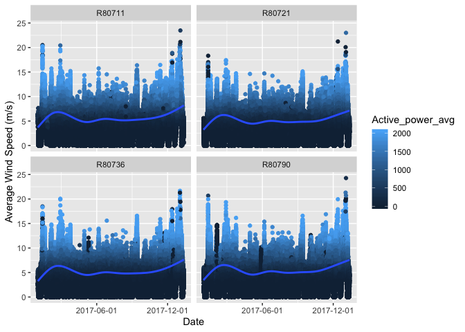

```r
ggplot(haute, aes(x = date, y = Wind_speed_avg)) +
  geom_point(aes(color = Active_power_avg))+
  geom_smooth() +
  labs(x = "Date", y = "Average Wind Speed (m/s)") +
  scale_x_date(date_breaks = "6 month") +
  facet_wrap(~Wind_turbine_name)
```

As an experiment, lets try to isolate the darkest spike in the R80790 time series. Since this is an unexpected lack of Active Power at high wind speeds, we’ll filter out that turbine, and filter a date range that will give us a better spread of data points in our plot, a nine day period in which the spike occurs. We’ll continue mapping Active Power to color, but change the date break to 1 day instead of 6 months so we can see which days exactly we are talking about. The plot, shown below, tells us that the spike from the plot above is really just a two day period, February 3rd and 4th of 2017, when despite the windy conditions, and the three other turbines producing power, this turbine was not producing. We might be able to figure out if it was down for service from looking at service records, or we can read into the data to figure out if something else was created a fault and if there might be a way to predicet that fault, if in fact it can be considered a fault.

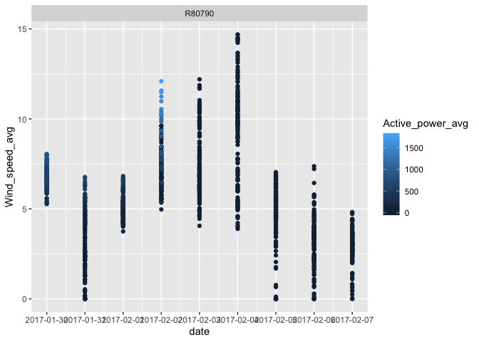

```r
haute %>%
  filter(date < as.Date("2017-02-8")) %>%
  filter(date > as.Date("2017-01-29")) %>%
  filter(Wind_turbine_name == "R80790") %>%
  ggplot(aes(x = date, y = Wind_speed_avg)) +
  geom_point(aes(color = Active_power_avg))+
  geom_smooth() +
  scale_x_date(date_breaks = "1 day") +
  facet_wrap(~Wind_turbine_name)
```

Now I’ll reproduce see the same exact plot but for all four turbines. Looks like the wind speed and active power are pretty similar across turbines that week, except where R80790 goes dark for two days.

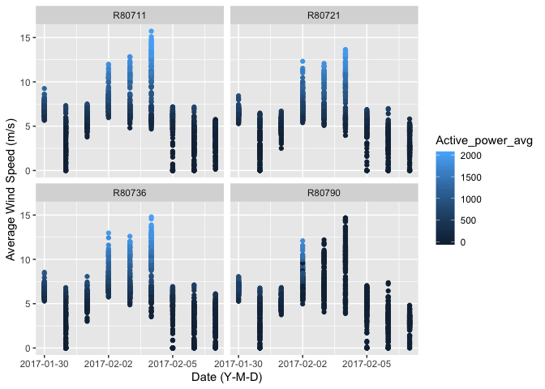

```r
haute %>%
  filter(date < as.Date("2017-02-8")) %>%
  filter(date > as.Date("2017-01-29")) %>%
  ggplot(aes(x = date, y = Wind_speed_avg)) +
  geom_point(aes(color = Active_power_avg))+
  geom_smooth() +
  labs(x = "Date (Y-M-D)", y = "Average Wind Speed (m/s)") +
  scale_x_date(date_breaks = "3 day") +
  facet_wrap(~Wind_turbine_name)
```

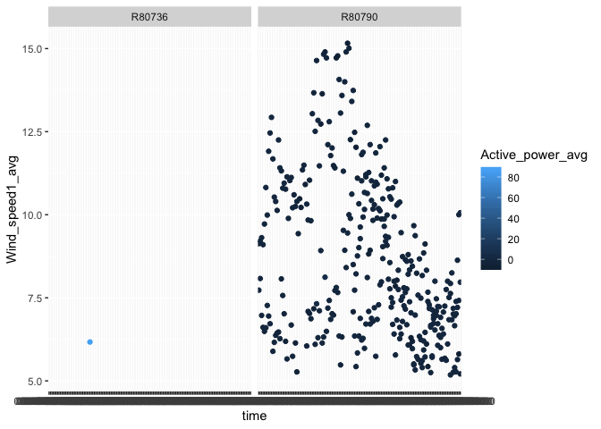

```r
haute %>%
  filter(date < as.Date("2017-02-5")) %>%
  filter(date > as.Date("2017-01-29")) %>%
  filter(Active_power_avg < 100) %>%
  filter(Wind_speed_avg > 5) %>%
    ggplot(aes(x = time, y = Wind_speed1_avg)) +
  geom_point(aes(color = Active_power_avg))+
  geom_smooth() +
  facet_wrap(~Wind_turbine_name)
```

Can I see the entire data set with these filters, when the wind speed is above 5 m/s?

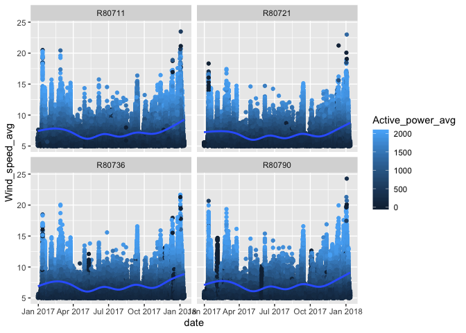

```r
haute %>%
  filter(Wind_speed_avg > 5) %>%
    ggplot(aes(x = date, y = Wind_speed_avg)) +
  geom_point(aes(color = Active_power_avg))+
  geom_smooth() +
  facet_wrap(~Wind_turbine_name)
```

**Other Variables Explored**

The grid operates at 50Hz, when does grid frequency drop below 50 Hertz, and does this tell us anything?:

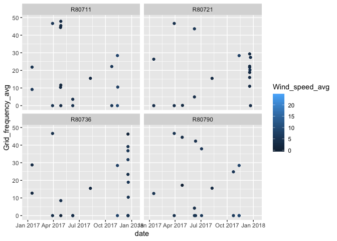

```r
ggplot(haute, aes(x = date, y = Grid_frequency_avg)) +
  geom_point(aes(color = Wind_speed_avg)) +
  facet_wrap(~Wind_turbine_name) +
  scale_y_continuous(limits = c(0,49))
```

The relationship between active and reactive power:

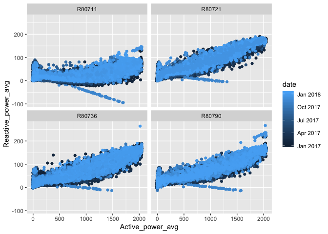

```r
ggplot(haute, aes(x = Active_power_avg, y = Reactive_power_avg, color = date)) +
  geom_point() +
  facet_wrap(~Wind_turbine_name)
```

In all 4 wind turbines there is a cluster offshoot where the relationship between active power and reactive power is inverted. This is interesting but may be beyond the scope of this project, and beyond my domain knowledge. I will stick with the relationship between wind speed and active power. In particular I am interested in those data points where Wind Speed is high enough that we would expect a certain level of Active Power, but in fact the Active Power is below a certain threshold. I will define this more specifically in the feature engineering phase of the project.